# Machine learning 1 assigment

## Introduction

The purpose of this assignment is to compare and study different methods and approaches in the classification of data. We want to focus on how different methods and their tuning parameters affect the expressiveness of the final model.

We chose four different methods:

- the knn,
- the linear regression,
- decision trees
- logistic regression.

For each method, we plot the error on the test and train dataset and evaluate the expressiveness of the models with different tuning parameters. For the evaluation of the methods, we used the Pima Indians Diabetes available in the R data utils.

#### Importing libraries and loading the data

```r
library("mlbench")
library("caTools")
library("class")
library(mice)
library(grid)
library("rpart")
library(GGally)
utils::data("PimaIndiansDiabetes2")
data <- PimaIndiansDiabetes2
```

#### Replacing NA values

After loading the data, we found out that some columns contain the NA values. Firstly we deleted all rows with this value, but these rows were too high. So secondly, we tried to replace the missing values with their averages, but this introduces much noise to the data. So finally, we used the mice library and its imputations methods for dealing with NA values.

```r
set.seed(101)
init = mice(data, maxit=0)
data <- complete(mice(data, method=init$method, predictorMatrix=init$predictorMatrix, m=5))
```

#### Summary of data

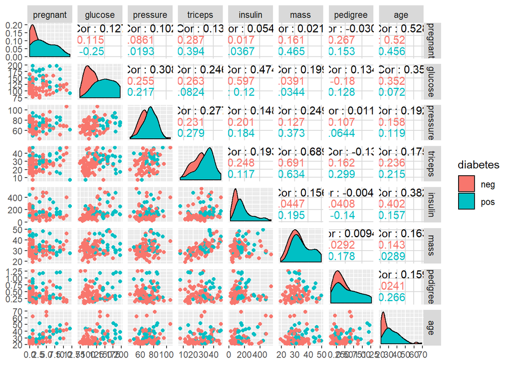

```r
p <- ggpairs(data[sample(1:nrow(data),100),], columns = 1:8, ggplot2::aes(colour=diabetes), lower = list(continuous=wrap("points")), progress=FALSE,legend=1)
p
```

#### Dividing the data into train and test dataset

```r
sample <- sample.split(data, SplitRatio = 0.8)
train <- subset(data, sample == TRUE)
test  <- subset(data, sample == FALSE)
trainDf <- train[, -9]
testDf <- test[,-9]
```

```r
#NA2mean <- function(x) replace(x, is.na(x), mean(x, na.rm = TRUE))
#trainDf <- replace(trainDf, TRUE, lapply(trainDf, NA2mean))
#testDf <- replace(testDf, TRUE, lapply(testDf, NA2mean))
#pred.classes <- knn(trainDf, testDf, train$diabetes, k=5)
#testDf <- cbind(testDf,pred.classes)
```

## KNN evaluation

We start with the knn method, whose parameter k represents the number of the neighbors. We plotted different evaluation metrics (accuracy, precision, and recall) for the test and train data for different values of the parameter k.

```r
ks <- c(1,3,5,7,9,11,15,17,23,25,35,45,55)# nearest neighbours to try
nks <- length(ks)
accuracy.train <- numeric(length=nks)
accuracy.test <- numeric(length=nks)
precision.train <- numeric(length=nks)
precision.test <- numeric(length=nks)
recall.train <- numeric(length=nks)
recall.test <- numeric(length=nks)
```

```r
for (i in seq(along=ks)) {
mod.train <- knn(trainDf,trainDf,k=ks[i],cl=train$diabetes)
confussionMatrixTrain = table(mod.train, train$diabetes)
accuracy.train[i] = sum(mod.train == train$diabetes)/length(train$diabetes)
precision.train[i] = confussionMatrixTrain[1,1]/sum(confussionMatrixTrain[,1])
recall.train[i] = confussionMatrixTrain[1,1]/sum(confussionMatrixTrain[1,])
mod.test <- knn(trainDf, testDf[,-9],k= ks[i],cl= train$diabetes)
confussionMatrixTest = table(mod.test, test$diabetes)
accuracy.test[i] = sum(mod.test == test$diabetes)/length(test$diabetes)
precision.test[i] = confussionMatrixTest[1,1]/sum(confussionMatrixTest[,1])
recall.test[i] = confussionMatrixTest[1,1]/sum(confussionMatrixTest[1,])
}
```

When we compare the train and the test line in the plot, we see that all evaluation metrics are in the train line at the maxim with k equals 1, because we return the real value.

#### Accuracy

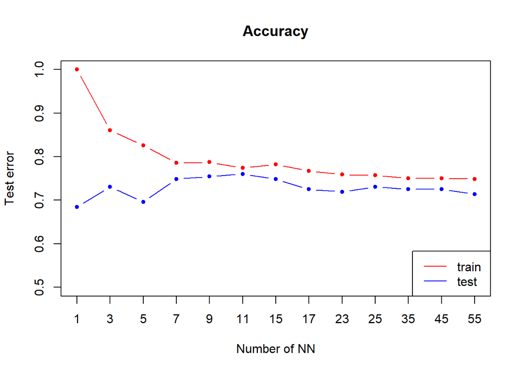

```r
plot(accuracy.train,xlab="Number of NN",ylab="Test error",type="n",xaxt="n", ylim=c(0.5, 1),  main="Accuracy")
axis(1, 1:length(ks), as.character(ks))
lines(accuracy.train,type="b",col='red',pch=20)
lines(accuracy.test,type="b",col='blue',pch=20)
legend("bottomright",lty=1,col=c("red","blue"),legend = c("train ", "test "))
```

#### Precision

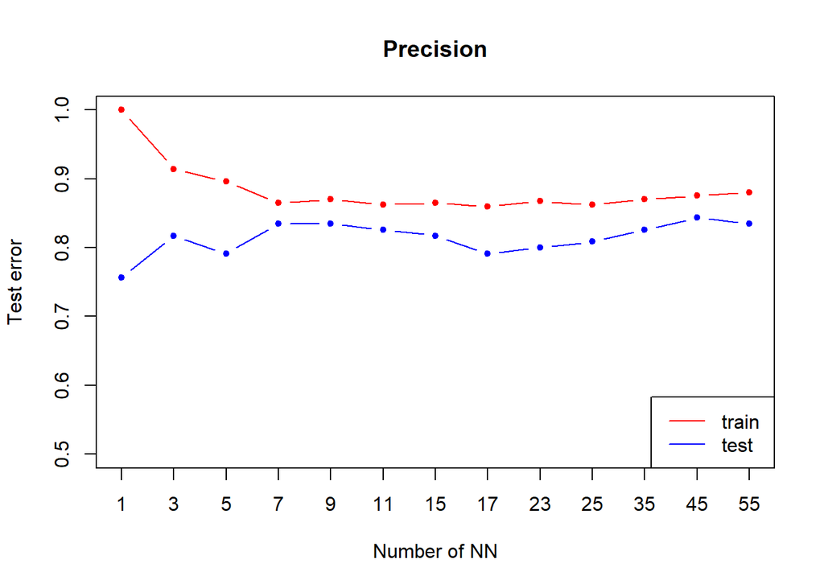

```r
plot(precision.train,xlab="Number of NN",ylab="Test error",type="n",xaxt="n", ylim=c(0.5, 1),  main="Precision")
axis(1, 1:length(ks), as.character(ks))
lines(precision.train,type="b",col='red',pch=20)
lines(precision.test,type="b",col='blue',pch=20)
legend("bottomright",lty=1,col=c("red","blue"),legend = c("train ", "test "))
```

#### Recall

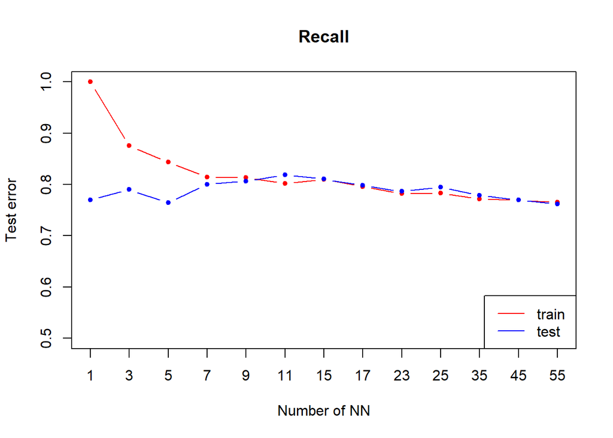

```r
plot(recall.train,xlab="Number of NN",ylab="Test error",type="n",xaxt="n", ylim=c(0.5, 1),  main="Recall")
axis(1, 1:length(ks), as.character(ks))
lines(recall.train,type="b",col='red',pch=20)
lines(recall.test,type="b",col='blue',pch=20)
legend("bottomright",lty=1,col=c("red","blue"),legend = c("train ", "test "))
```

### Plotting the boundaries in different dimensions

We implemented the function plot.knn to visualize the boundaries in the given columns of indexA and indexB, and then show these two dimensions.

```r
col1<-c('blue', 'magenta')
plot.knn <- function(k, indexA, indexB) {
  grid.A <- seq(min(data[,indexA]), max(data[,indexA]), (max(data[,indexA]) - min(data[,indexA])) / 100)
  grid.B <- seq(min(data[,indexB]), max(data[,indexB]), (max(data[,indexB]) - min(data[,indexB])) / 100)
  grid <- expand.grid(grid.A,grid.B)
  colnames(grid) <- colnames(trainDf[, c(indexA, indexB)])
  predicted.classes <- knn(trainDf[, c(indexA, indexB)], grid, train$diabetes, k=k)
  plot(data[, indexA], data[ ,indexB], pch=20, col=col1[as.numeric(data$diabetes)], xlab=colnames(data)[indexA], ylab=colnames(data)[indexB])
  points(grid[, 1], grid[,2], pch='.', col=col1[as.numeric(predicted.classes)])  # draw grid
  legend("topleft", legend=levels(data$diabetes),fill =col1)
  title(c("Classification with k=", k))
  predicted.matrix <- matrix(as.numeric(predicted.classes), length(grid.A), length(grid.B))
  contour(grid.A, grid.B, predicted.matrix, levels=c(1.5), drawlabels=FALSE,add=TRUE)
}
```

#### Glucose and Age

Plotting of the boundaries between columns glucose and age

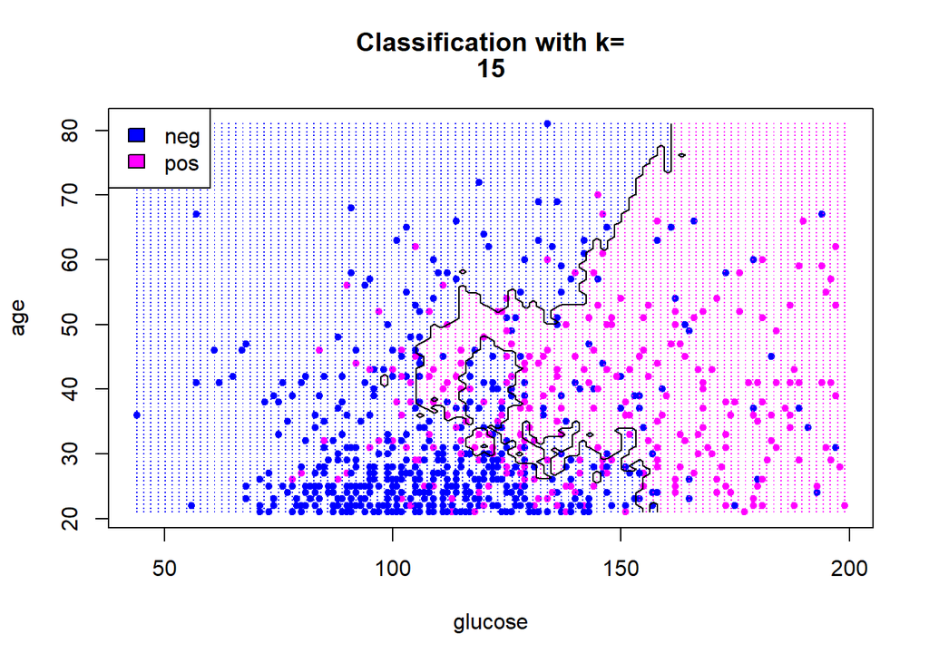

```r
plot.knn(15, 2, 8)
```

#### Pressure and Mass

Plotting of the boundaries between columns pressure and mass

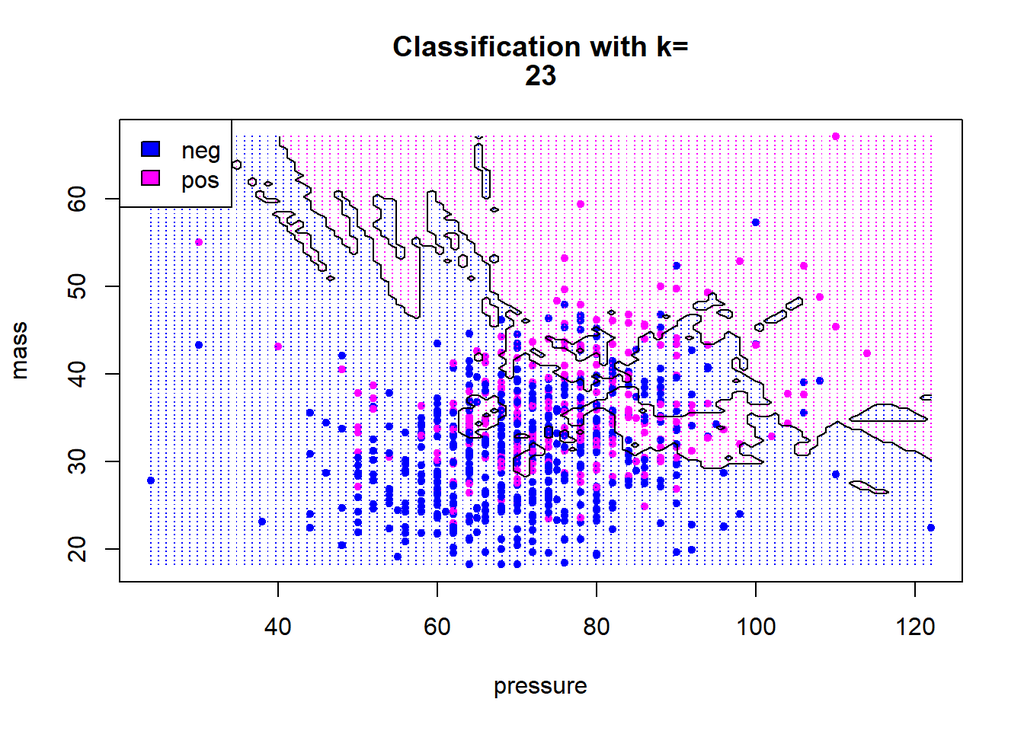

```r
plot.knn(23, 3, 6)
```

#### Triceps and insulin

Plotting of the boundaries between columns triceps and insulin

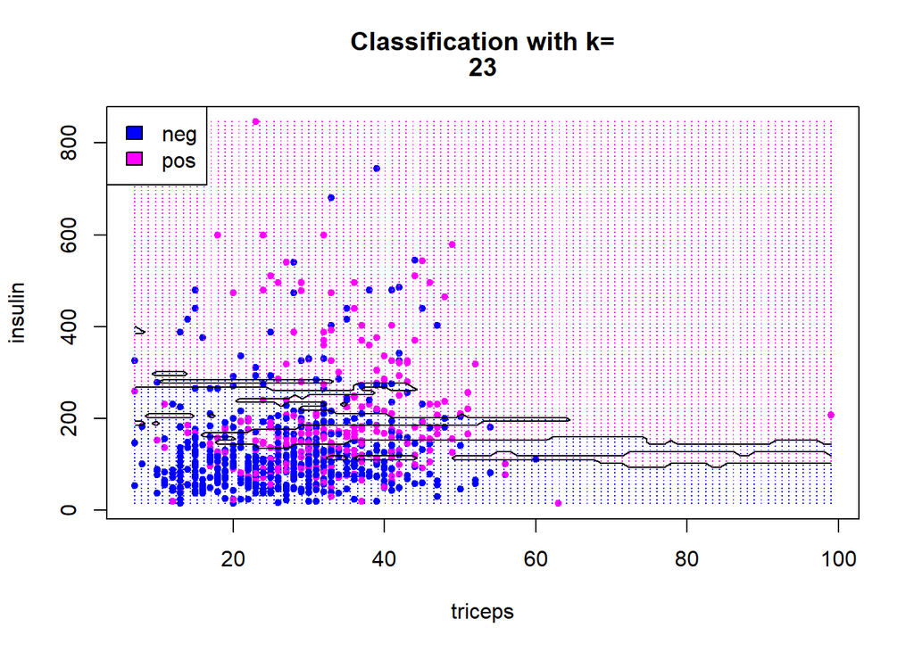

```r
plot.knn(23, 4, 5)
```

#### Pedigree and Age

Plotting of the boundaries between columns age and pedigree

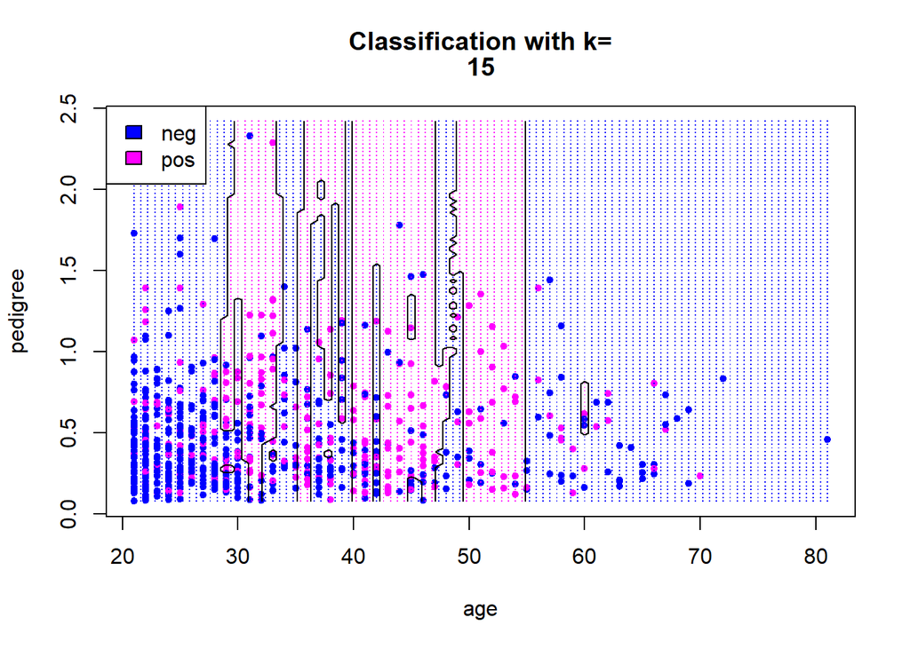

```r
plot.knn(15, 8, 7)
```

### Plotting the boundaties in the first two PCA components

```r
res.pca <- prcomp(data[,1:8], scale = TRUE)
plot.knn.pca <- function(k) {
  pca.values <- prcomp(trainDf)$x
  grid.PC1 <- seq(min(pca.values[,1]), max(pca.values[,1]), 5)
  grid.PC2 <- seq(min(pca.values[,2]), max(pca.values[,2]), 1)
  grid <- expand.grid(grid.PC1,grid.PC2)
  colnames(grid) <- c('PC1','PC2')
  predicted.classes <- knn(pca.values[,c(1,2)], grid, train$diabetes, k=k)
  plot(pca.values[,1], pca.values[,2], pch=20, col=col1[as.numeric(train$diabetes)], xlab='PC1', ylab='PC2')
  points(grid$PC1, grid$PC2, pch='.', col=col1[as.numeric(predicted.classes)])  # draw grid
  legend("topleft", legend=levels(data$diabetes),fill =col1)
  title(c("PCA Classification with k=", k))

  predicted.matrix <- matrix(as.numeric(predicted.classes), length(grid.PC1), length(grid.PC2))
  contour(grid.PC1, grid.PC2, predicted.matrix, levels=c(1.5), drawlabels=FALSE,add=TRUE)
}
```

We tried plotting the first two principal components with a different value of the k, and we can see that this parameter affects the smoothness of the boundaries contour. With the higher value of k, the contour is smoother, and the boundaries are less specific. For example, we see that the model with k equals one is obviously overfitting the train data.

#### k = 1

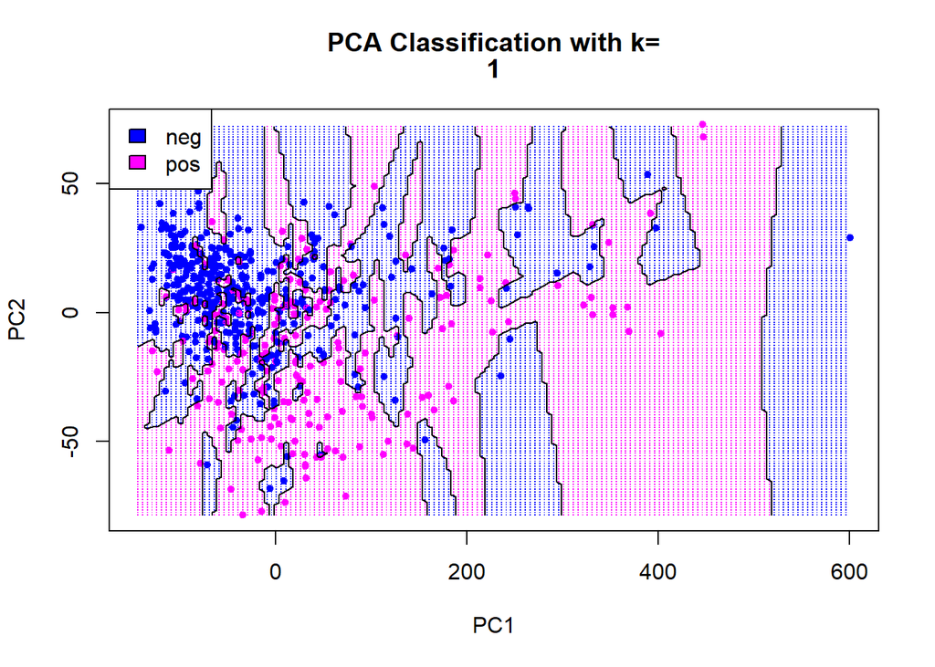

```r
plot.knn.pca(1)
```

#### k = 7

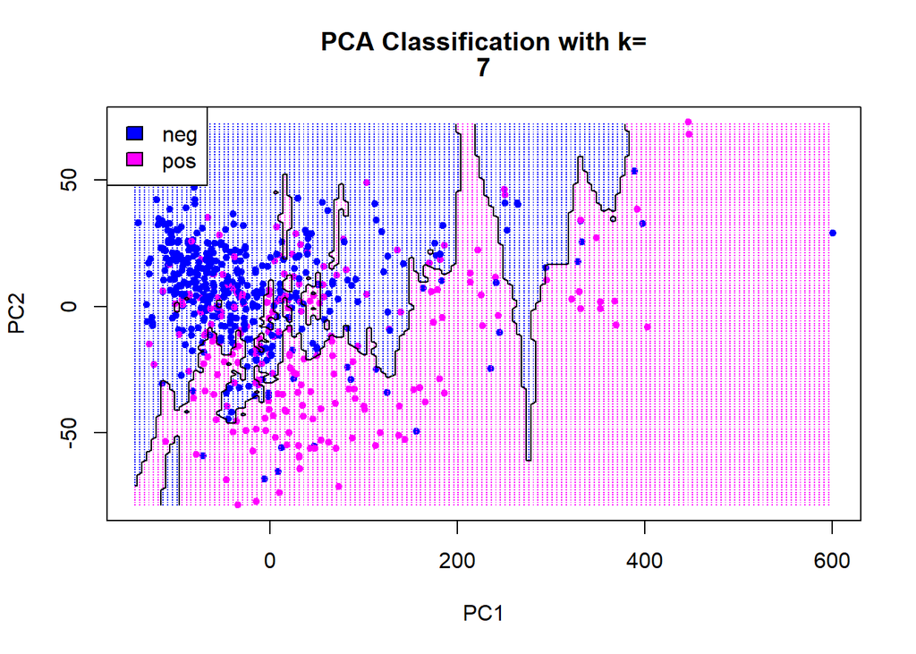

```r
plot.knn.pca(7)
```

#### k = 15

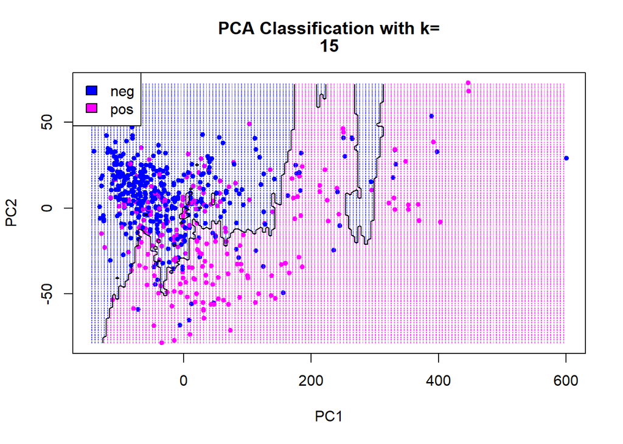

```r
plot.knn.pca(15)
```

#### k = 23

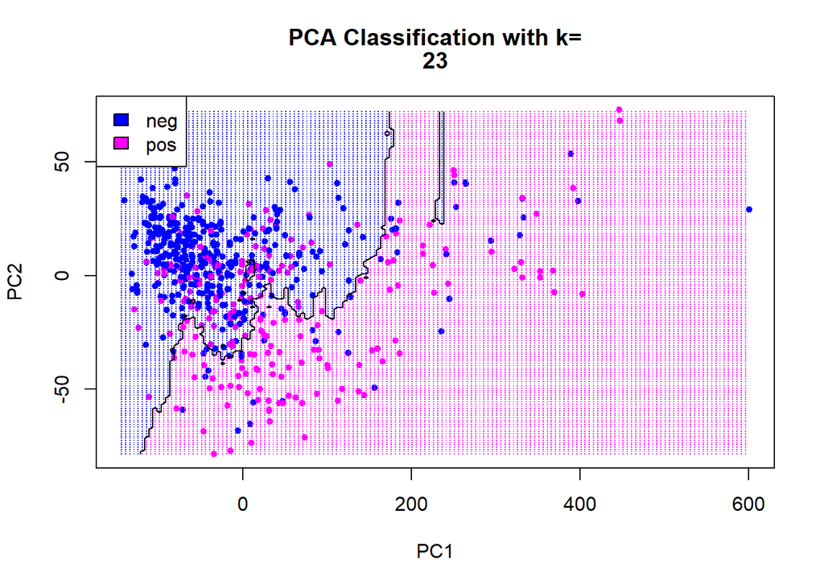

```r
plot.knn.pca(23)
```

#### k = 50

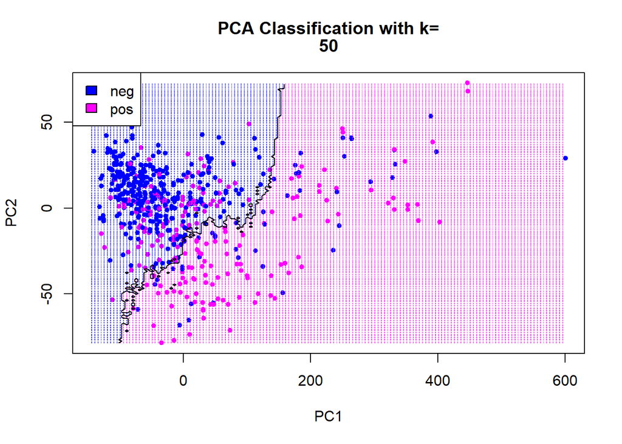

```r
plot.knn.pca(50)
```

#### k = 100

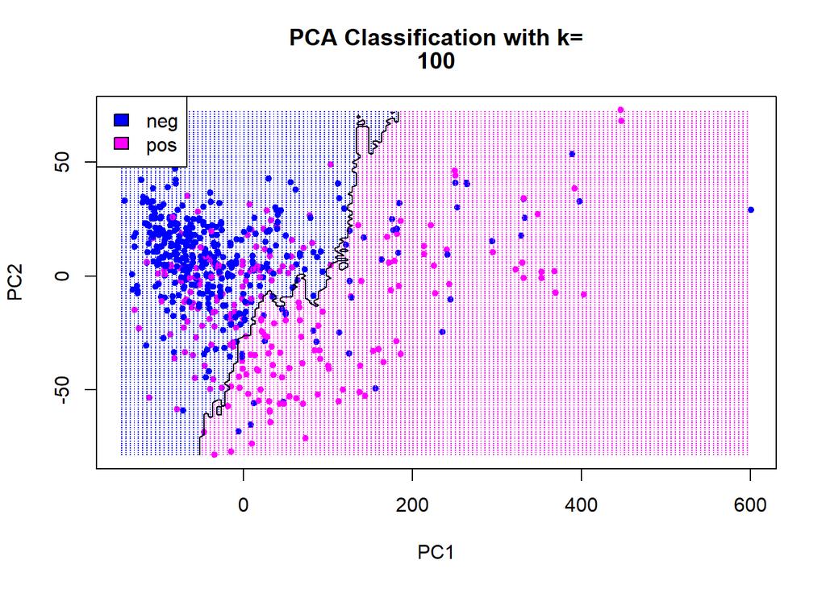

```r
plot.knn.pca(100)
```

## Logistic regression

Firstly in the logistic regression method, we tried the model with all columns of the data. Then we saw that the columns insulin, age, pressure, and triceps have higher p-value then 5%, so in the final model, they are not significant.

```r
glm <- glm(diabetes~.,family=binomial(logit),data=train)
summary(glm)
```

```
##
## Call:
## glm(formula = diabetes ~ ., family = binomial(logit), data = train)
##
## Deviance Residuals:
##     Min       1Q   Median       3Q      Max
## -2.7802  -0.7521  -0.4165   0.7210   2.3011
##
## Coefficients:
##               Estimate Std. Error z value Pr(>|z|)
## (Intercept) -8.8065214  0.9218204  -9.553  < 2e-16 ***
## pregnant     0.0974263  0.0362116   2.690  0.00714 **
## glucose      0.0367428  0.0046411   7.917 2.44e-15 ***
## pressure    -0.0123576  0.0097888  -1.262  0.20680
## triceps      0.0107334  0.0137321   0.782  0.43443
## insulin     -0.0005421  0.0011242  -0.482  0.62966
## mass         0.0874873  0.0221514   3.950 7.83e-05 ***
## pedigree     0.9076200  0.3398162   2.671  0.00756 **
## age          0.0176546  0.0110235   1.602  0.10926
## ---
## Signif. codes:  0 '***' 0.001 '**' 0.01 '*' 0.05 '.' 0.1 ' ' 1
##
## (Dispersion parameter for binomial family taken to be 1)
##
##     Null deviance: 776.76  on 596  degrees of freedom
## Residual deviance: 563.64  on 588  degrees of freedom
## AIC: 581.64
##
## Number of Fisher Scoring iterations: 5
```

So we made the second model only with remaining significant variables. Furthermore, we discovered that all the remaining variables are significant.

```r
glm2 <- glm(diabetes~pregnant + glucose + mass + pedigree,family=binomial(logit),data=train)
summary(glm2)
```

```
##
## Call:
## glm(formula = diabetes ~ pregnant + glucose + mass + pedigree,
##     family = binomial(logit), data = train)
##
## Deviance Residuals:
##     Min       1Q   Median       3Q      Max
## -2.8519  -0.7376  -0.4274   0.7189   2.3821
##
## Coefficients:
##              Estimate Std. Error z value Pr(>|z|)
## (Intercept) -8.948893   0.779941 -11.474  < 2e-16 ***
## pregnant     0.124819   0.030341   4.114 3.89e-05 ***
## glucose      0.036290   0.003943   9.203  < 2e-16 ***
## mass         0.088487   0.016632   5.320 1.04e-07 ***
## pedigree     0.902777   0.338891   2.664  0.00772 **
## ---
## Signif. codes:  0 '***' 0.001 '**' 0.01 '*' 0.05 '.' 0.1 ' ' 1
##
## (Dispersion parameter for binomial family taken to be 1)
##
##     Null deviance: 776.76  on 596  degrees of freedom
## Residual deviance: 567.85  on 592  degrees of freedom
## AIC: 577.85
##
## Number of Fisher Scoring iterations: 5
```

### The evaluation for the logistic regression

```r
    predicted.classes.train <- predict(glm2, trainDf, type = "response")
    predicted.classes.train <- sapply(predicted.classes.train, function(x) round(x) + 1)
    confussionMatrixTrain = table(predicted.classes.train, train$diabetes)
    logr.accuracy.train <- (confussionMatrixTrain[1,1] + confussionMatrixTrain[2,2]) / length(predicted.classes.train)
    logr.precision.train <- confussionMatrixTrain[1,1]/sum(confussionMatrixTrain[,1])
    logr.recall.train <- confussionMatrixTrain[1,1]/sum(confussionMatrixTrain[1,])

    predicted.classes.test <- predict(glm2, testDf, type = "response")
    predicted.classes.test <- sapply(predicted.classes.test, function(x) round(x) + 1)

    confussionMatrixTest <- table(predicted.classes.test, test$diabetes)
    logr.accuracy.test <- (confussionMatrixTest[1,1] + confussionMatrixTest[2,2]) / length(predicted.classes.test)
    logr.precision.test <- confussionMatrixTest[1,1]/sum(confussionMatrixTest[,1])
    logr.recall.test <- confussionMatrixTest[1,1]/sum(confussionMatrixTest[1,])
```

##### Accuracy of the model is on the train dataset is 0.7788945.

##### Precision of the model is on the train dataset is 0.8935065.

##### Recall of the model is on the train dataset is 0.7908046.

##### Accuracy of the model is on the test dataset is 0.7660819.

##### Precision of the model is on the test dataset is 0.8086957.

##### Recall of the model is on the test dataset is 0.8378378.

### Boundaries of logistic regression in different variables

```r
plot.logRegression.boundaries <- function(indexA, indexB) {
  grid.A <- seq(min(data[,indexA]), max(data[,indexA]), (max(data[,indexA]) - min(data[,indexA])) / 100)
  grid.B <- seq(min(data[,indexB]), max(data[,indexB]), (max(data[,indexB]) - min(data[,indexB])) / 100)
  grid <- expand.grid(grid.A,grid.B)
  colnames(grid) <- colnames(trainDf[, c(indexA, indexB)])

  glm2 <- glm(diabetes~.,family=binomial(logit),data = train[, c(indexA, indexB, 9)])
  predicted.classes <- predict(glm2, grid, type = "response")
  predicted.classes <- lapply(predicted.classes, function(x) round(x) + 1)

  plot(data[, indexA], data[ ,indexB], pch=20, col=col1[as.numeric(data$diabetes)], xlab=colnames(data)[indexA], ylab=colnames(data)[indexB])

  points(grid[, 1], grid[,2], pch='.', col=col1[as.numeric(predicted.classes)])  # draw grid
  legend("topleft", legend=levels(data$diabetes),fill =col1)
  title(c("Classification with logistic regression"))
  predicted.matrix <- matrix(as.numeric(predicted.classes), length(grid.A), length(grid.B))
  contour(grid.A, grid.B, predicted.matrix, levels=c(1.5), drawlabels=FALSE,add=TRUE)
}
```

Glucose and age

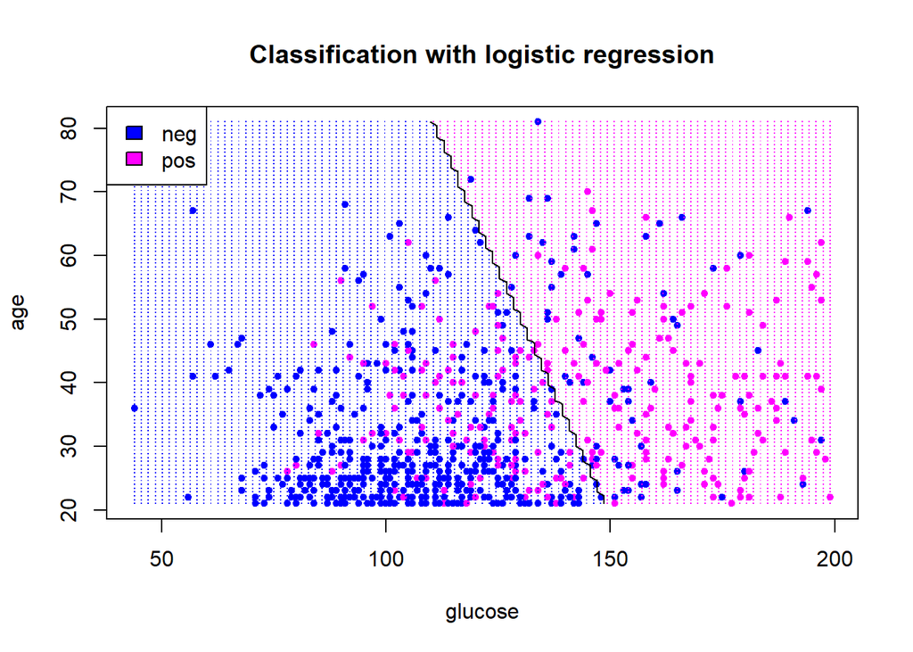

```r
plot.logRegression.boundaries(2, 8)
```

Pressure and mass

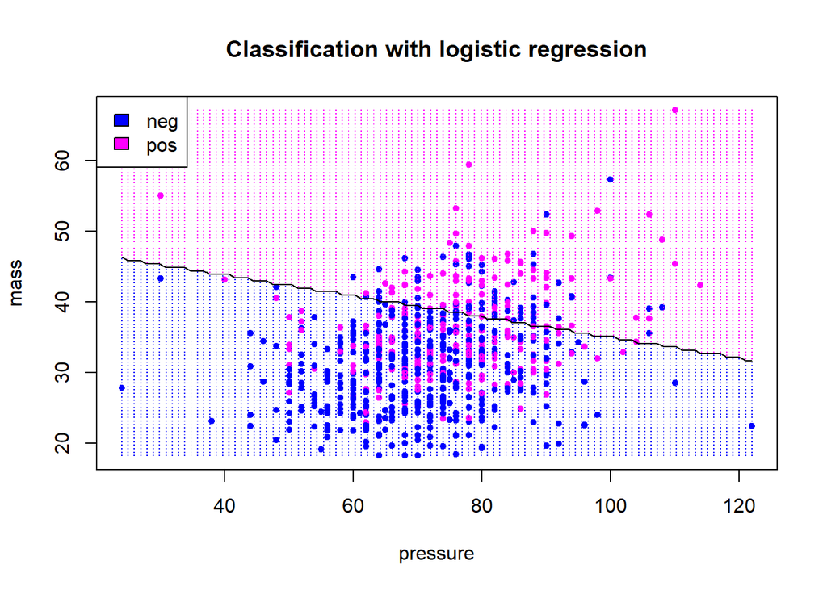

```r
plot.logRegression.boundaries(3, 6)
```

Triceps and insulin

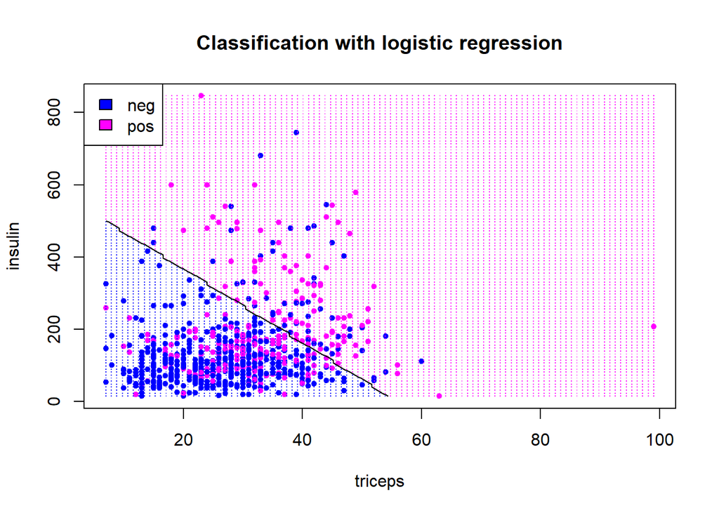

```r
plot.logRegression.boundaries(4, 5)
```

Age and pedigree

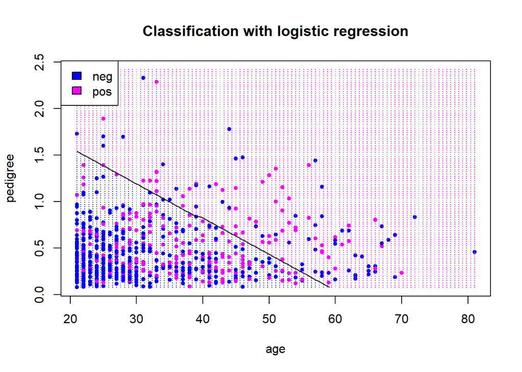

```r
plot.logRegression.boundaries(8, 7)
```

### Bundaries of logistic regression in PCA

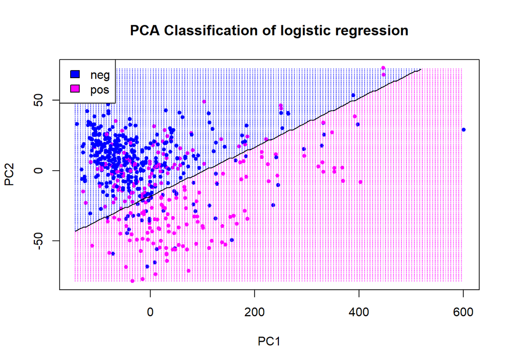

```r
plot.logRegression.pca <- function() {
  pca.values <- prcomp(trainDf)$x
  pca.df <- as.data.frame.matrix(pca.values[,c(1,2)])
  pca.df$diabetes <- train$diabetes

  grid.PC1 <- seq(min(pca.values[,1]), max(pca.values[,1]), 5)
  grid.PC2 <- seq(min(pca.values[,2]), max(pca.values[,2]), 1)
  grid <- expand.grid(grid.PC1,grid.PC2)
  colnames(grid) <- c('PC1','PC2')

  glm2 <- glm(diabetes~.,family=binomial(logit),data=pca.df)
  predicted.classes <- predict(glm2, grid, type = "response")
  predicted.classes <- lapply(predicted.classes, function(x) round(x) + 1)
  plot(pca.values[,1], pca.values[,2], pch=20, col=col1[as.numeric(train$diabetes)], xlab='PC1', ylab='PC2')
  points(grid$PC1, grid$PC2, pch='.', col=col1[as.numeric(predicted.classes)])  # draw grid
  legend("topleft", legend=levels(data$diabetes),fill =col1)
  title(c("PCA Classification of logistic regression"))

  predicted.matrix <- matrix(as.numeric(predicted.classes), length(grid.PC1), length(grid.PC2))
  contour(grid.PC1, grid.PC2, predicted.matrix, levels=c(1.5), drawlabels=FALSE,add=TRUE)
}
plot.logRegression.pca()
```

## CART

In the cart method, we used for restraining the depth of the tree the parameter minbucket, which controls the minimum size of the leaves of the tree. Then we plot the test and train error for each bucket to find out the best value for the parameter minbucket.

```r
possible_bucket_sizes <- seq(1, 300, 10)
nks <- length(possible_bucket_sizes)
accuracy.train <- numeric(length=nks)
accuracy.test <- numeric(length=nks)
precision.train <- numeric(length=nks)
precision.test <- numeric(length=nks)
recall.train <- numeric(length=nks)
recall.test <- numeric(length=nks)
for(i in seq(1:length(possible_bucket_sizes))){
  cart_model <- rpart(diabetes ~., data = train, method = "class",control = rpart.control(minbucket = possible_bucket_sizes[i]))
  predicted.classes.test <- predict(cart_model, testDf, type = "class")
  predicted.classes.train <- predict(cart_model, trainDf, type = "class")
    confussionMatrixTrain = table(predicted.classes.train, train$diabetes)
    accuracy.train[i] <- mean(predicted.classes.train == train$diabetes)
    precision.train[i] = confussionMatrixTrain[1,1]/sum(confussionMatrixTrain[,1])
    recall.train[i] = confussionMatrixTrain[1,1]/sum(confussionMatrixTrain[1,])
    confussionMatrixTest = table(predicted.classes.test, test$diabetes)
    accuracy.test[i] <- mean(predicted.classes.test == test$diabetes)
    precision.test[i] = confussionMatrixTest[1,1]/sum(confussionMatrixTest[,1])
    recall.test[i] = confussionMatrixTest[1,1]/sum(confussionMatrixTest[1,])
}
```

#### Accuracy

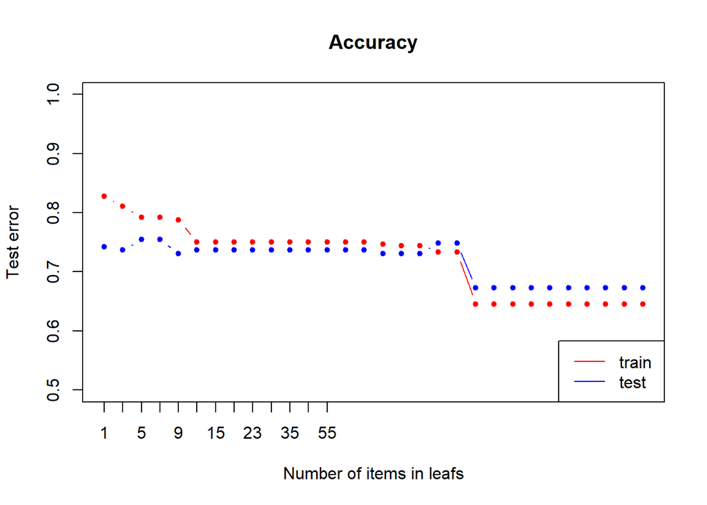

```r
plot(accuracy.train,xlab="Number of items in leafs",ylab="Test error",type="n",xaxt="n", ylim=c(0.5, 1),  main="Accuracy",)
axis(1, 1:length(ks), as.character(ks))
lines(accuracy.train,type="b",col='red',pch=20)
lines(accuracy.test,type="b",col='blue',pch=20)
legend("bottomright",lty=1,col=c("red","blue"),legend = c("train ", "test "))
```

#### Precision

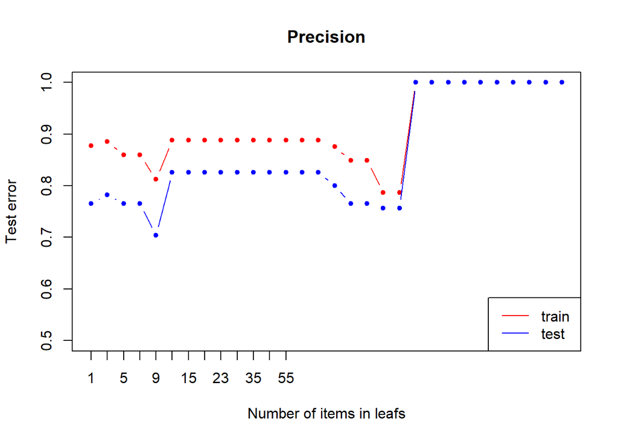

```r
plot(precision.train,xlab="Number of items in leafs",ylab="Test error",type="n",xaxt="n", ylim=c(0.5, 1),  main="Precision",)
axis(1, 1:length(ks), as.character(ks))
lines(precision.train,type="b",col='red',pch=20)
lines(precision.test,type="b",col='blue',pch=20)
legend("bottomright",lty=1,col=c("red","blue"),legend = c("train ", "test "))
```

#### Recall

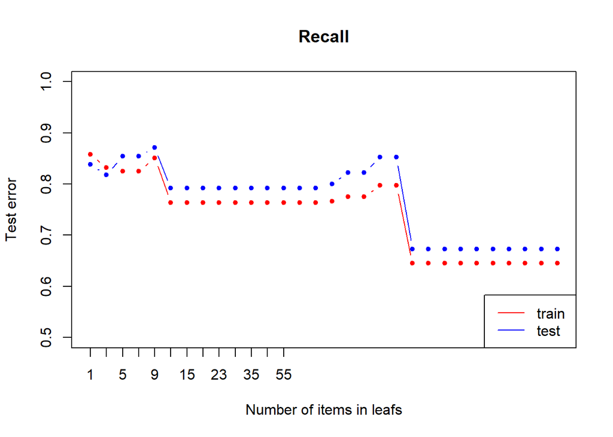

```r
plot(recall.train,xlab="Number of items in leafs",ylab="Test error",type="n",xaxt="n", ylim=c(0.5, 1),  main="Recall",)
axis(1, 1:length(ks), as.character(ks))
lines(recall.train,type="b",col='red',pch=20)
lines(recall.test,type="b",col='blue',pch=20)
legend("bottomright",lty=1,col=c("red","blue"),legend = c("train ", "test "))
```

```r
plot.treeBoundaries <- function(mb, indexA, indexB) {
  grid.A <- seq(min(data[,indexA]), max(data[,indexA]), (max(data[,indexA]) - min(data[,indexA])) / 100)
  grid.B <- seq(min(data[,indexB]), max(data[,indexB]), (max(data[,indexB]) - min(data[,indexB])) / 100)
  grid <- expand.grid(grid.A,grid.B)
  colnames(grid) <- colnames(trainDf[, c(indexA, indexB)])

  cart_model <- rpart(diabetes ~ . , data = train[, c(indexA, indexB, 9)], method = "class",control = rpart.control(minbucket = mb))
  predicted.classes <- predict(cart_model, grid, type = "class")

  plot(data[, indexA], data[ ,indexB], pch=20, col=col1[as.numeric(data$diabetes)], xlab=colnames(data)[indexA], ylab=colnames(data)[indexB])

  points(grid[, 1], grid[,2], pch='.', col=col1[as.numeric(predicted.classes)])  # draw grid
  legend("topleft", legend=levels(data$diabetes),fill =col1)
  title(c("Classification with minibucket size=", mb))
  predicted.matrix <- matrix(as.numeric(predicted.classes), length(grid.A), length(grid.B))
  contour(grid.A, grid.B, predicted.matrix, levels=c(1.5), drawlabels=FALSE,add=TRUE)
}
```

Plotting of the boundaries between columns glucose and age

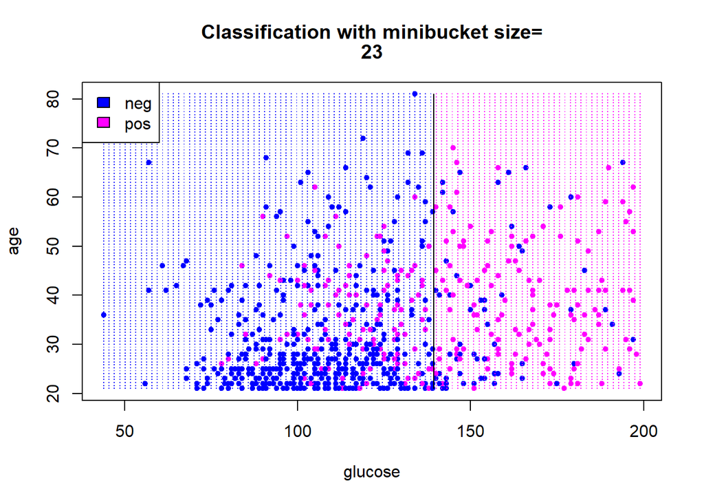

```r
plot.treeBoundaries(23, 2, 8)
```

Plotting of the boundaries between columns pressure and mass

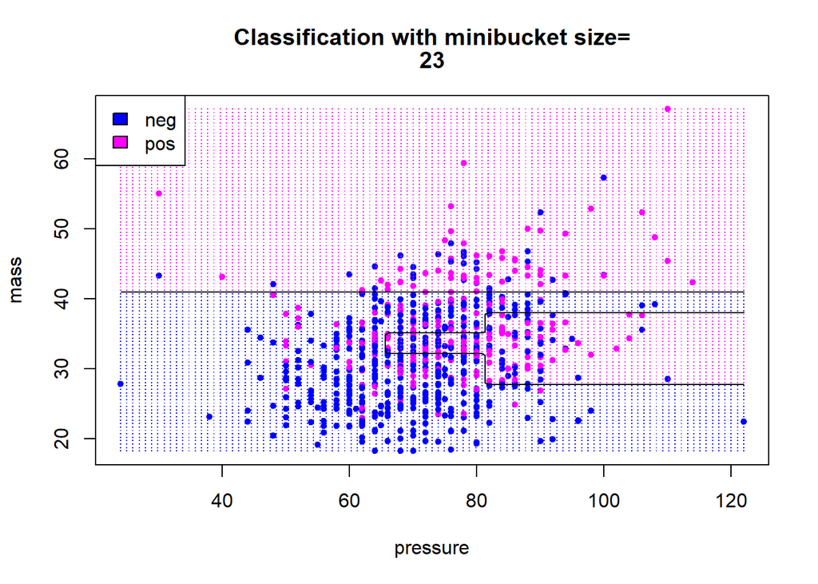

```r
plot.treeBoundaries(23,3, 6)
```

Plotting of the boundaries between columns triceps and insulin

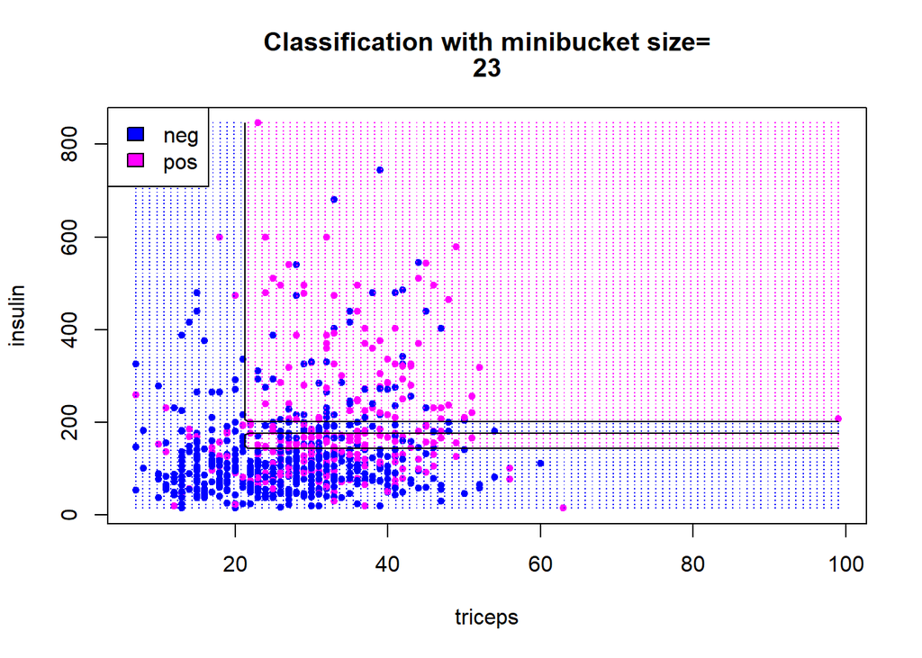

```r
plot.treeBoundaries(23,4, 5)
```

Plotting of the boundaries between columns age and pedigree

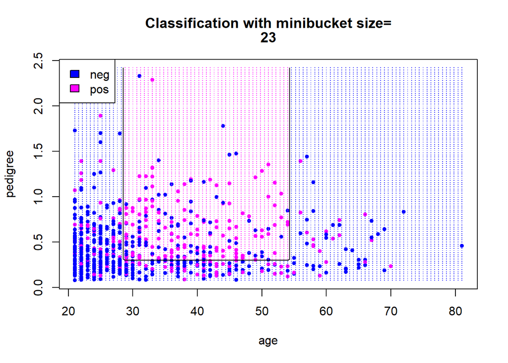

```r
plot.treeBoundaries(23, 8, 7)
```